# Case Study Assignment for Data Engineer - Merkle

## Alexis Peringer

### 23/10/2025

# Exploratory Analysis

```python
import pandas as pd
import matplotlib.pyplot as plt
import seaborn as sns
import io
import json

sns.set_theme(style="whitegrid", palette="muted")
plt.rcParams['figure.figsize'] = (10, 6)
pd.set_option('display.max_colwidth', None)
```

This dataset is a sample of logs of user behavior events streamed from a social marketplace or a C2C platform data.

it collects:

- which users are viewing which products/users, when, and on what device
- server assignments of A/B testing experiments and groups

two distinct types of tables:

- item (dimension)
- event (fact)

--> both joined by ITEM primary key 'id' and EVENT foreign key 'parameter_value'

### 1. Item

- dimension table: product catalog
- describes what is being sold on the platform
- adjective + category + modifier = name

#### 1.A. Initial Item Inspection

```python
item_df = pd.read_csv('item.csv')
display(item_df.head())

print(f"\n--- Shape (item.csv) ---")
print(f"Rows: {item_df.shape[0]}, Columns: {item_df.shape[1]}")

print("\n--- Data Types and Nulls (item.csv) ---\n")
item_df.info()
```

|  | adjective | category | created_at | id | modifier | name | price |
| --- | --- | --- | --- | --- | --- | --- | --- |
| 0 | fuzzy | contraption | 2014-01-15 21:36:09 | 2512.0 | carrying_case | fuzzy contraption carrying_case | 150.0 |
| 1 | NaN | instrument | 2013-05-14 05:20:50 | 482.0 | refill | instrument refill | 35.2 |
| 2 | industrial-strength | module | 2014-02-04 19:28:32 | 2446.0 | NaN | industrial-strength module | 300.0 |
| 3 | digital | tool | 2013-02-25 12:23:18 | 1312.0 | carrying_case | digital tool carrying_case | 16.5 |
| 4 | miniature | device | 2013-08-05 17:20:45 | 3556.0 | cleaner | miniature device cleaner | 16.5 |

```
--- Shape (item.csv) ---

--- Data Types and Nulls (item.csv) ---

<class 'pandas.core.frame.DataFrame'>
RangeIndex: 2198 entries, 0 to 2197
Data columns (total 7 columns):
 #   Column      Non-Null Count  Dtype
---  ------      --------------  -----
 0   adjective   1926 non-null   object
 1   category    2198 non-null   object
 2   created_at  2198 non-null   object
 3   id          2198 non-null   float64
 4   modifier    1432 non-null   object
 5   name        2198 non-null   object
 6   price       2198 non-null   float64
dtypes: float64(2), object(5)
memory usage: 120.3+ KB
```

#### 1.B. Quantify Missing Item Data

```python
missing_counts = item_df.isnull().sum()
missing_percent = (missing_counts / len(item_df) * 100).round(2)
missing_df = pd.DataFrame({'count': missing_counts, 'percent': missing_percent})

print("--- Missing Values (item.csv) ---")
display(missing_df[missing_df['count'] > 0])
```

```
--- Missing Values (item.csv) ---
```

|  | count | percent |
| --- | --- | --- |
| adjective | 272 | 12.37 |
| modifier | 766 | 34.85 |

#### 1.C. Analyze Numerical Data (Price)

```
--- Summary Statistics for 'price' ---
```

```
count    2198.000000
mean       98.157420
std       156.059937
min         0.000000
25%        13.750000
50%        42.000000
75%       115.700000
max      2250.000000
Name: price, dtype: float64
```

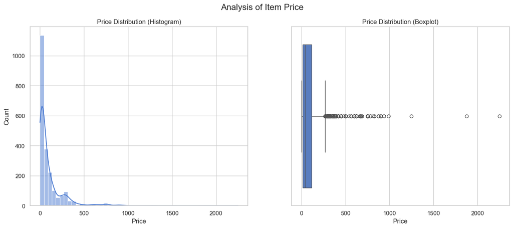

```python
print("--- Summary Statistics for 'price' ---")
display(item_df['price'].describe())

fig, axes = plt.subplots(1, 2, figsize=(16, 6))

sns.histplot(item_df['price'], bins=50, kde=True, ax=axes[0])
axes[0].set_title('Price Distribution (Histogram)')
axes[0].set_xlabel('Price')

sns.boxplot(x=item_df['price'], ax=axes[1])
axes[1].set_title('Price Distribution (Boxplot)')
axes[1].set_xlabel('Price')

plt.suptitle('Analysis of Item Price', fontsize=16)
plt.show()
```

#### 1.D. Analyze Categorical Data

```
Unique categories: 10
Unique adjectives: 13
Unique modifiers: 9
```

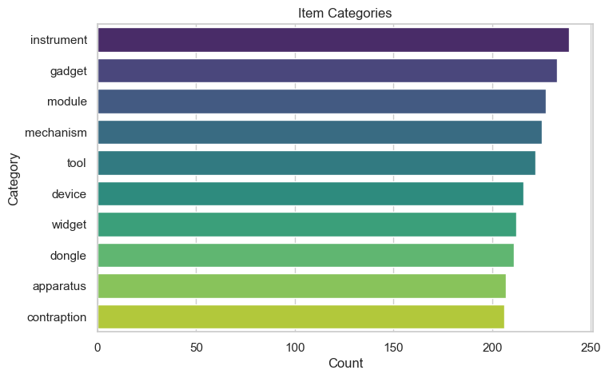

```python
print(f"Unique categories: {item_df['category'].nunique()}")
print(f"Unique adjectives: {item_df['adjective'].nunique()}")
print(f"Unique modifiers: {item_df['modifier'].nunique()}")

top_categories = item_df['category'].value_counts()

plt.figure(figsize=(8, 5))

sns.barplot(x=top_categories.values, y=top_categories.index, hue=top_categories.index, palette='viridis', legend=False)
plt.title('Item Categories')
plt.xlabel('Count')
plt.ylabel('Category')
plt.show()
```

#### 1.E. Analyze Datetime Data (created_at)

```
Date Range: 2013-02-22 14:29:32 to 2014-02-25 23:57:08
```

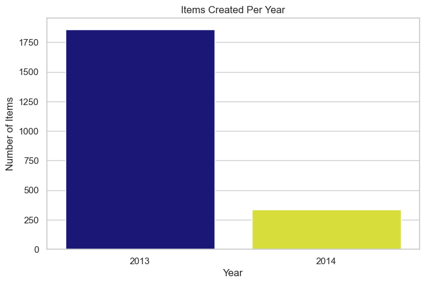

```python
# 1. Convert to datetime
item_df['created_at'] = pd.to_datetime(item_df['created_at'])

# 2. Get range
print(f"Date Range: {item_df['created_at'].min()} to {item_df['created_at'].max()}")

# 3. Feature Engineering: Extract year
item_df['creation_year'] = item_df['created_at'].dt.year

# 4. Visualize items created per year
plt.figure(figsize=(8, 5))

sns.countplot(x=item_df['creation_year'], hue=item_df['creation_year'], palette='plasma', legend=False)
plt.title('Items Created Per Year')
plt.xlabel('Year')
plt.ylabel('Number of Items')
plt.show()
```

### 2. Event

- fact table: user behavior logs
- tracking user engagement with the items
- users from a specific platform perform actions on specific products at a specific times

#### 2.A. Initial Event Inspection

```python
events_df = pd.read_csv('event.csv')

display(events_df.head())

print(f"\n--- Shape (events.csv) ---")
print(f"Rows: {events_df.shape[0]}, Columns: {events_df.shape[1]}")

print("\n--- Data Types and Nulls (events.csv) ---\n")
events_df.info()
```

|  | event_id | event_time | user_id | event.payload |
| --- | --- | --- | --- | --- |
| 0 | b9de71c5c3cc4cd7a97e50b832106e5a | 2017-06-26 11:23:39 | 178481.0 | {"event_name":"view_item","platform":"android","parameter_name":"item_id","parameter_value":"3526"} |
| 1 | 23267713c9ea44419331731f50b6a8db | 2017-06-27 10:46:39 | 178481.0 | {"event_name":"view_item","platform":"android","parameter_name":"item_id","parameter_value":"1514"} |
| 2 | 1b7822fa7b854e01970218ae8f721fe0 | 2017-06-27 11:15:39 | 178481.0 | {"event_name":"view_item","platform":"android","parameter_name":"item_id","parameter_value":"3712"} |
| 3 | 2a7a188a626841ac94befcc419f06af4 | 2016-10-05 20:43:10 | 154133.0 | {"event_name":"view_item","platform":"android","parameter_name":"item_id","parameter_value":"3586"} |
| 4 | 631d657264cc4616a4528f759509b25d | 2016-10-04 03:29:10 | 154133.0 | {"event_name":"view_item","platform":"android","parameter_name":"item_id","parameter_value":"1061"} |

```
--- Shape (events.csv) ---

--- Data Types and Nulls (events.csv) ---

<class 'pandas.core.frame.DataFrame'>
RangeIndex: 853640 entries, 0 to 853639
Data columns (total 4 columns):
 #   Column         Non-Null Count   Dtype
---  ------         --------------   -----
 0   event_id       853640 non-null  object
 1   event_time     853640 non-null  object
 2   user_id        853640 non-null  float64
 3   event.payload  853640 non-null  object
dtypes: float64(1), object(3)
memory usage: 26.1+ MB
```

#### 2.B. Parse JSON Payload

```python
if events_df is not None:

    # 1. Define a robust JSON parsing function
    def parse_json(payload):
        try:
            return json.loads(payload)
        except (json.JSONDecodeError, TypeError):
            return None # Return None for bad data or nulls

    # 2. Apply the function to each row
    payloads = events_df['event.payload'].apply(parse_json)

    # 3. Drop rows where JSON parsing failed
    original_count = len(payloads)
    payloads = payloads.dropna()
    print(f"Successfully parsed {len(payloads)} rows.")
    print(f"Dropped {original_count - len(payloads)} rows with bad/missing JSON.")

    # 4. Convert the resulting Series of dictionaries into a new DataFrame
    payload_df = pd.DataFrame(payloads.tolist())

    # 5. Concatenate the new payload columns with the original DataFrame
    events_df_flat = pd.concat([events_df.loc[payloads.index].drop('event.payload', axis=1), payload_df.set_index(payloads.index)], axis=1)

    print("--- Flattened DataFrame (events.csv) ---")
    display(events_df_flat.head())

    print("\n--- New Data Types and Nulls (events.csv) ---")
    events_df_flat.info()
else:
    print("events_df not loaded. Skipping JSON parsing.")
    events_df_flat = None # Set to None so subsequent cells can check
```

```
Successfully parsed 853640 rows.
Dropped 0 rows with bad/missing JSON.
--- Flattened DataFrame (events.csv) ---
```

|  | event_id | event_time | user_id | event_name | platform | parameter_name | parameter_value |
| --- | --- | --- | --- | --- | --- | --- | --- |
| 0 | b9de71c5c3cc4cd7a97e50b832106e5a | 2017-06-26 11:23:39 | 178481.0 | view_item | android | item_id | 3526 |
| 1 | 23267713c9ea44419331731f50b6a8db | 2017-06-27 10:46:39 | 178481.0 | view_item | android | item_id | 1514 |
| 2 | 1b7822fa7b854e01970218ae8f721fe0 | 2017-06-27 11:15:39 | 178481.0 | view_item | android | item_id | 3712 |
| 3 | 2a7a188a626841ac94befcc419f06af4 | 2016-10-05 20:43:10 | 154133.0 | view_item | android | item_id | 3586 |
| 4 | 631d657264cc4616a4528f759509b25d | 2016-10-04 03:29:10 | 154133.0 | view_item | android | item_id | 1061 |

```
--- New Data Types and Nulls (events.csv) ---
<class 'pandas.core.frame.DataFrame'>
Index: 853640 entries, 0 to 853639
Data columns (total 7 columns):
 #   Column           Non-Null Count   Dtype
---  ------           --------------   -----
 0   event_id         853640 non-null  object
 1   event_time       853640 non-null  object
 2   user_id          853640 non-null  float64
 3   event_name       853640 non-null  object
 4   platform         853640 non-null  object
 5   parameter_name   853640 non-null  object
 6   parameter_value  853640 non-null  object
dtypes: float64(1), object(6)
memory usage: 52.1+ MB
```

#### 2.C. Analyze Event Categorical Data

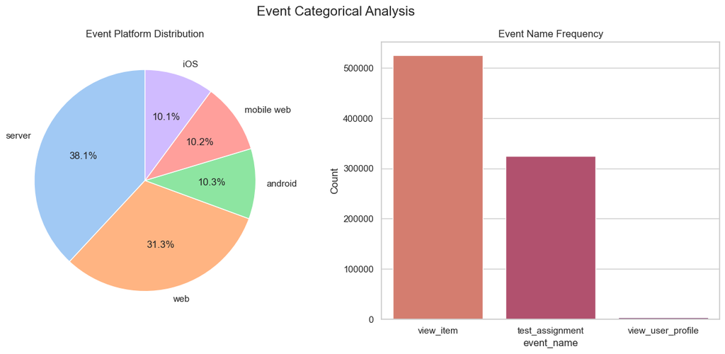

```
--- Parameter Name Counts ---
parameter_name
item_id            262786
referrer           262786
test_assignment    162490
test_id            162490
viewed_user_id       3088
Name: count, dtype: int64
```

```python
if events_df_flat is not None:
    fig, axes = plt.subplots(1, 2, figsize=(16, 6))

    # 1. Analyze 'platform'
    platform_counts = events_df_flat['platform'].value_counts()
    axes[0].pie(platform_counts, labels=platform_counts.index, autopct='%1.1f%%', startangle=90, colors=sns.color_palette('pastel'))
    axes[0].set_title('Event Platform Distribution')

    # 2. Analyze 'event_name'
    event_name_counts = events_df_flat['event_name'].value_counts()

    sns.barplot(x=event_name_counts.index, y=event_name_counts.values, ax=axes[1], palette='flare', hue=event_name_counts.index, legend=False)
    axes[1].set_title('Event Name Frequency')
    axes[1].set_ylabel('Count')

    plt.suptitle('Event Categorical Analysis', fontsize=16)
    plt.show()

    print("\n--- Parameter Name Counts ---")
    print(events_df_flat['parameter_name'].value_counts())
else:
    print("events_df_flat not created. Skipping event categorical analysis.")
```

#### Drill down analysis of parameters values

- users can either view other users or items
- referrers metrics (home, shopping cart, etc.)
- some users are assigned experiments (test_id) for some features (e.g. search algorithms, buttons, feed, etc..)
- each test assignment is divided in a control group and test group (A/B testing)

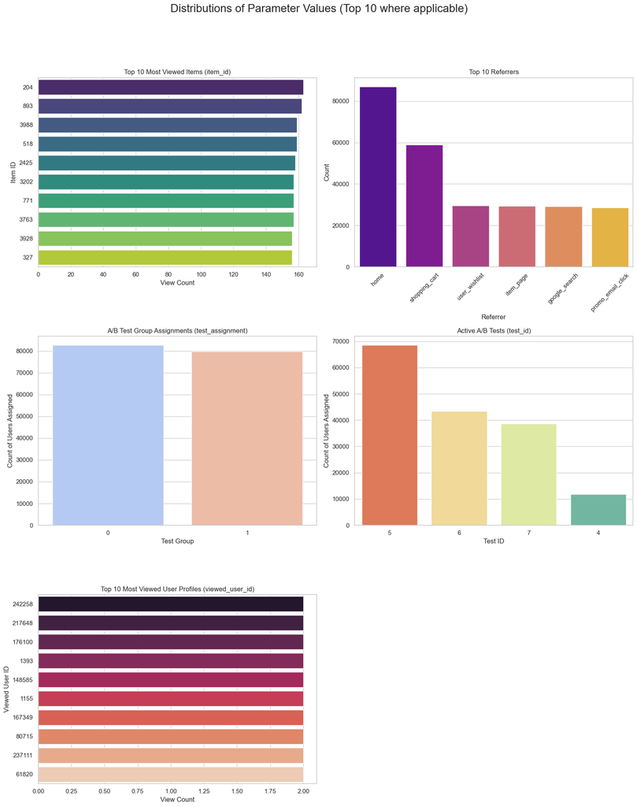

```python
# Check if the DataFrame exists and is not empty
if 'events_df_flat' in locals() and events_df_flat is not None and not events_df_flat.empty:

    # Create a 3x2 grid of plots.
    fig, axes = plt.subplots(3, 2, figsize=(16, 20))
    fig.suptitle('Distributions of Parameter Values (Top 10 where applicable)', fontsize=20, y=1.03)

    # Flatten the axes array for easier indexing
    ax_flat = axes.flatten()

    try:
        # --- 1. Top 10 Most Viewed Items (item_id) ---
        item_id_data = events_df_flat[events_df_flat['parameter_name'] == 'item_id']['parameter_value']
        item_id_counts = item_id_data.value_counts().head(10)
        sns.barplot(ax=ax_flat[0], x=item_id_counts.values, y=item_id_counts.index.astype(str),
                    hue=item_id_counts.index.astype(str), palette='viridis', legend=False)
        ax_flat[0].set_title('Top 10 Most Viewed Items (item_id)')
        ax_flat[0].set_xlabel('View Count')
        ax_flat[0].set_ylabel('Item ID')

        # --- 2. Top 10 Referrers ---
        referrer_data = events_df_flat[events_df_flat['parameter_name'] == 'referrer']['parameter_value']
        referrer_counts = referrer_data.value_counts().head(10)
        sns.barplot(ax=ax_flat[1], x=referrer_counts.index, y=referrer_counts.values,
                    hue=referrer_counts.index, palette='plasma', legend=False)
        ax_flat[1].set_title('Top 10 Referrers')
        ax_flat[1].set_xlabel('Referrer')
        ax_flat[1].set_ylabel('Count')
        ax_flat[1].tick_params(axis='x', rotation=45) # Rotate labels if they overlap

        # --- 3. A/B Test Group Assignments ---
        test_assign_data = events_df_flat[events_df_flat['parameter_name'] == 'test_assignment']['parameter_value']
        test_assign_counts = test_assign_data.value_counts()
        sns.barplot(ax=ax_flat[2], x=test_assign_counts.index, y=test_assign_counts.values,
                    hue=test_assign_counts.index, palette='coolwarm', legend=False)
        ax_flat[2].set_title('A/B Test Group Assignments (test_assignment)')
        ax_flat[2].set_xlabel('Test Group')
        ax_flat[2].set_ylabel('Count of Users Assigned')

        # --- 4. A/B Test IDs ---
        test_id_data = events_df_flat[events_df_flat['parameter_name'] == 'test_id']['parameter_value']
        test_id_counts = test_id_data.value_counts()
        sns.barplot(ax=ax_flat[3], x=test_id_counts.index, y=test_id_counts.values,
                    hue=test_id_counts.index.astype(str), palette='Spectral', legend=False)
        ax_flat[3].set_title('Active A/B Tests (test_id)')
        ax_flat[3].set_xlabel('Test ID')
        ax_flat[3].set_ylabel('Count of Users Assigned')

        # --- 5. Top 10 Most Viewed User Profiles ---
        viewed_user_data = events_df_flat[events_df_flat['parameter_name'] == 'viewed_user_id']['parameter_value']
        viewed_user_counts = viewed_user_data.value_counts().head(10)
        sns.barplot(ax=ax_flat[4], x=viewed_user_counts.values, y=viewed_user_counts.index.astype(str),
                    hue=viewed_user_counts.index.astype(str), palette='rocket', legend=False)
        ax_flat[4].set_title('Top 10 Most Viewed User Profiles (viewed_user_id)')
        ax_flat[4].set_xlabel('View Count')
        ax_flat[4].set_ylabel('Viewed User ID')

        # --- 6. Hide the last empty subplot ---
        ax_flat[5].axis('off')

        # Adjust layout to prevent overlap
        plt.tight_layout(rect=[0, 0.03, 1, 0.98])
        plt.show()

    except Exception as e:
        print(f"An error occurred while plotting: {e}")
        print("This might be due to an unexpected data type in 'parameter_value'.")

else:
    print("events_df_flat not loaded or is empty. Please re-run the JSON parsing cell.")
```

#### 2.D. Analyze Event Datetime Data

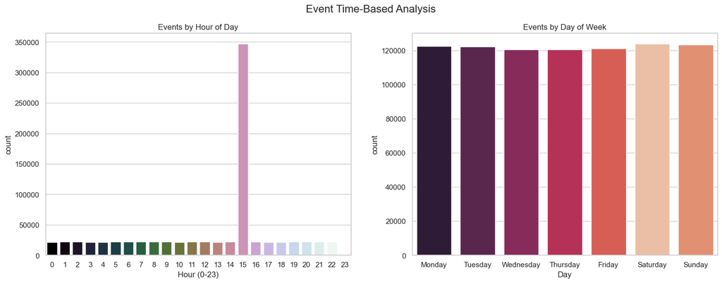

```python
if events_df_flat is not None:
    events_df_flat['event_time'] = pd.to_datetime(events_df_flat['event_time'])

    # Feature Engineering: Extract hour of day and day of week
    events_df_flat['event_hour'] = events_df_flat['event_time'].dt.hour
    events_df_flat['event_dow'] = events_df_flat['event_time'].dt.day_name()

    fig, axes = plt.subplots(1, 2, figsize=(18, 6))

    # 1. Plot activity by hour
    sns.countplot(x=events_df_flat['event_hour'], ax=axes[0], palette='cubehelix', hue=events_df_flat['event_hour'], legend=False)
    axes[0].set_title('Events by Hour of Day')
    axes[0].set_xlabel('Hour (0-23)')

    # 2. Plot activity by day of week
    dow_order = ['Monday', 'Tuesday', 'Wednesday', 'Thursday', 'Friday', 'Saturday', 'Sunday']
    sns.countplot(x=events_df_flat['event_dow'], ax=axes[1], palette='rocket', order=dow_order, hue=events_df_flat['event_dow'], legend=False)
    axes[1].set_title('Events by Day of Week')
    axes[1].set_xlabel('Day')

    plt.suptitle('Event Time-Based Analysis', fontsize=16)
    plt.show()
else:
    print("events_df_flat not created. Skipping event datetime analysis.")
```

#### Analysis of the 3pm spike

- top 10 users: pattern of 12 events each
- platform: server
- event_time: 15h23
- parameter_name: test_assignment, test_id

--> daily scheduled backend job each day at 15h22-3

--> massively parallel distributed batch job (likely spark)

--> purpose: A/B test assignments to users by the server

--> needs to be filtered out for user behavior analysis

--> df_real_users = events_df_flat[events_df_flat['platform'] != 'server']

```python
if events_df_flat is not None:
    try:
        # Ensure the datetime and hour columns exist before filtering
        if 'event_hour' not in events_df_flat.columns:
            print("Creating 'event_hour' column...")
            events_df_flat['event_time'] = pd.to_datetime(events_df_flat['event_time'])
            events_df_flat['event_hour'] = events_df_flat['event_time'].dt.hour
            print("Done.")

        # 1. Filter the DataFrame for only the 3 PM spike
        df_3pm = events_df_flat[events_df_flat['event_hour'] == 15]

        if df_3pm.empty:
            print("No events found for hour 15. The spike might be at a different hour.")
        else:
            print(f"--- Analysis of {len(df_3pm)} Events at 3 PM ---")

            # 2. Check for suspicious patterns:

            # Is it all one user? (e.g., a 'service-account' user)
            print("\n--- Top 10 Users at 3 PM ---")
            print(df_3pm['user_id'].value_counts().head(10))

            # Is it all one platform?
            print("\n--- Platforms at 3 PM ---")
            print(df_3pm['platform'].value_counts())

            # Do all events happen at exactly 15:00:00?
            print("\n--- Event Minutes at 3 PM ---")
            # This checks if they all piled up in the first minute of the hour
            print(df_3pm['event_time'].dt.minute.value_counts().head())

            # --- NEW ANALYSIS: What is this job DOING? ---

            print("\n--- Event Names during 3 PM spike ---")
            # This will likely show 'test_assignment' is the dominant event
            print(df_3pm['event_name'].value_counts())

            print("\n--- Parameter Names during 3 PM spike ---")
            param_names_3pm = df_3pm['parameter_name'].value_counts()
            print(param_names_3pm)

            # Now, let's look at the values for the top parameter names

            if 'test_assignment' in param_names_3pm.index:
                print("\n--- Values for 'test_assignment' (at 3 PM) ---")
                print(df_3pm[df_3pm['parameter_name'] == 'test_assignment']['parameter_value'].value_counts())

            if 'test_id' in param_names_3pm.index:
                print("\n--- Values for 'test_id' (at 3 PM) ---")
                print(df_3pm[df_3pm['parameter_name'] == 'test_id']['parameter_value'].value_counts())

            # Check if any 'view_item' events are also in this spike
            if 'item_id' in param_names_3pm.index:
                print(f"\n--- Found {param_names_3pm['item_id']} 'view_item' events in spike ---")
                print("--- Top 5 'item_id's viewed (at 3 PM) ---")
                print(df_3pm[df_3pm['parameter_name'] == 'item_id']['parameter_value'].value_counts().head())
            # --- END NEW ANALYSIS ---

    except Exception as e:
        print(f"An error occurred during analysis: {e}")
        print("Please ensure 'events_df_flat' is loaded correctly.")

else:
    print("events_df_flat not loaded. Please re-run the previous cells.")
```

```
--- Analysis of 346860 Events at 3 PM ---

--- Top 10 Users at 3 PM ---
user_id
218338.0    12
83723.0     12
182455.0    12
188021.0    12
250577.0    12
238175.0    12
217729.0    12
213938.0    12
164315.0    12
125523.0    12
Name: count, dtype: int64

--- Platforms at 3 PM ---
platform
server        324980
web            11048
iOS             3715
android         3573
mobile web      3544
Name: count, dtype: int64

--- Event Minutes at 3 PM ---
event_time
23    301571
22     24183
30       427
41       420
55       415
Name: count, dtype: int64

--- Event Names during 3 PM spike ---
event_name
test_assignment      324980
view_item             21738
view_user_profile       142
Name: count, dtype: int64
```

[output cut: 18 more lines]

```
5    68563
6    43390
7    38647
4    11890
Name: count, dtype: int64

--- Found 10869 'view_item' events in spike ---
--- Top 5 'item_id's viewed (at 3 PM) ---
parameter_value
2489    14
2331    13
3866    12
2380    12
355     12
Name: count, dtype: int64
```

```
--- Plotting Analysis of 346860 Events at 3 PM ---
```

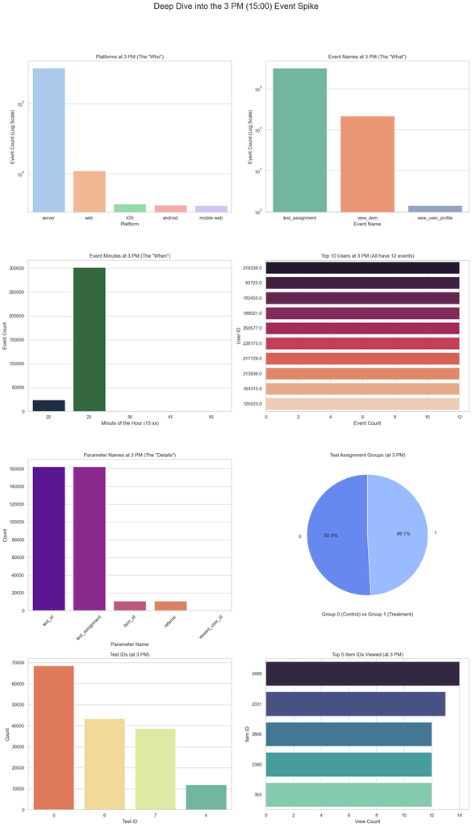

```python
if 'df_3pm' in locals() and df_3pm is not None:
    print(f"--- Plotting Analysis of {len(df_3pm)} Events at 3 PM ---")

    # --- 1. Pre-calculate all the data series from your output ---
    platform_counts = df_3pm['platform'].value_counts()
    minute_counts = df_3pm['event_time'].dt.minute.value_counts().head()
    event_name_counts = df_3pm['event_name'].value_counts()
    user_counts = df_3pm['user_id'].value_counts().head(10)

    param_names_3pm = df_3pm['parameter_name'].value_counts()

    # Filter for param_name == 'test_assignment' to get its values
    assign_counts = df_3pm[df_3pm['parameter_name'] == 'test_assignment']['parameter_value'].value_counts()

    # Filter for param_name == 'test_id' to get its values
    testid_counts = df_3pm[df_3pm['parameter_name'] == 'test_id']['parameter_value'].value_counts()

    # Filter for param_name == 'item_id' to get its values
    item_counts = df_3pm[df_3pm['parameter_name'] == 'item_id']['parameter_value'].value_counts().head()

    # --- 2. Create the 4x2 plot grid ---
    fig, axes = plt.subplots(4, 2, figsize=(16, 28))
    fig.suptitle('Deep Dive into the 3 PM (15:00) Event Spike', fontsize=20, y=1.02)

    # --- Plot 1: Platforms (Bar Chart) ---
    # CHANGED from pie to bar for readability
    sns.barplot(ax=axes[0, 0], x=platform_counts.index, y=platform_counts.values,
                palette='pastel', hue=platform_counts.index, legend=False)
    axes[0, 0].set_title('Platforms at 3 PM (The "Who")')
    axes[0, 0].set_ylabel('Event Count')
    axes[0, 0].set_xlabel('Platform')
    # Set y-axis to log scale to see small values
    axes[0, 0].set_yscale('log')
    axes[0, 0].set_ylabel('Event Count (Log Scale)')


    # --- Plot 2: Event Names (Bar Chart) ---
    # CHANGED from pie to bar for readability
    sns.barplot(ax=axes[0, 1], x=event_name_counts.index, y=event_name_counts.values,
                palette='Set2', hue=event_name_counts.index, legend=False)
    axes[0, 1].set_title('Event Names at 3 PM (The "What")')
    axes[0, 1].set_ylabel('Event Count')
    axes[0, 1].set_xlabel('Event Name')
    # Set y-axis to log scale to see small values
    axes[0, 1].set_yscale('log')
    axes[0, 1].set_ylabel('Event Count (Log Scale)')


    # --- Plot 3: Event Minutes (Bar) ---
    sns.barplot(ax=axes[1, 0], x=minute_counts.index, y=minute_counts.values,
                palette='cubehelix', hue=minute_counts.index.astype(str), legend=False)
    axes[1, 0].set_title('Event Minutes at 3 PM (The "When")')
    axes[1, 0].set_xlabel('Minute of the Hour (15:xx)')
    axes[1, 0].set_ylabel('Event Count')

    # --- Plot 4: Top 10 Users (Bar) ---
    sns.barplot(ax=axes[1, 1], x=user_counts.values, y=user_counts.index.astype(str),
                palette='rocket', hue=user_counts.index.astype(str), legend=False)
    axes[1, 1].set_title('Top 10 Users at 3 PM (All have 12 events)')
    axes[1, 1].set_xlabel('Event Count')
    axes[1, 1].set_ylabel('User ID')

    # --- Plot 5: Parameter Names (Bar) ---
    sns.barplot(ax=axes[2, 0], x=param_names_3pm.index, y=param_names_3pm.values,
                palette='plasma', hue=param_names_3pm.index, legend=False)
    axes[2, 0].set_title('Parameter Names at 3 PM (The "Details")')
    axes[2, 0].set_xlabel('Parameter Name')
    axes[2, 0].set_ylabel('Count')
    axes[2, 0].tick_params(axis='x', rotation=45)

    # --- Plot 6: Test Assignments (Pie Chart) ---
    # KEPT as pie chart because it's a perfect 50/50 split
    axes[2, 1].pie(assign_counts, labels=assign_counts.index, autopct='%1.1f%%',
                   startangle=90, colors=sns.color_palette('coolwarm'))
    axes[2, 1].set_title('Test Assignment Groups (at 3 PM)')
    axes[2, 1].set_xlabel('Group 0 (Control) vs Group 1 (Treatment)')


    # --- Plot 7: Test IDs (Bar) ---
    sns.barplot(ax=axes[3, 0], x=testid_counts.index, y=testid_counts.values,
                palette='Spectral', hue=testid_counts.index.astype(str), legend=False)
    axes[3, 0].set_title('Test IDs (at 3 PM)')
    axes[3, 0].set_xlabel('Test ID')
    axes[3, 0].set_ylabel('Count')

    # --- Plot 8: Top 5 Item IDs (Bar) ---
    sns.barplot(ax=axes[3, 1], x=item_counts.values, y=item_counts.index.astype(str),
                palette='mako', hue=item_counts.index.astype(str), legend=False)
    axes[3, 1].set_title('Top 5 Item IDs Viewed (at 3 PM)')
    axes[3, 1].set_xlabel('View Count')
    axes[3, 1].set_ylabel('Item ID')

    plt.tight_layout(rect=[0, 0.03, 1, 0.98])
    plt.show()

elif 'events_df_flat' in locals() and events_df_flat is not None:
    print("Error: 'df_3pm' not found. Please re-run the previous cell that filters the DataFrame.")
else:
    print("Error: 'events_df_flat' not loaded. Please re-run the full notebook.")
```

#### Analysis of view_item event distribution throughout the day (is there a correlation with test_assignment?)

- no both event aren't correlated, that amount of view_item is normal

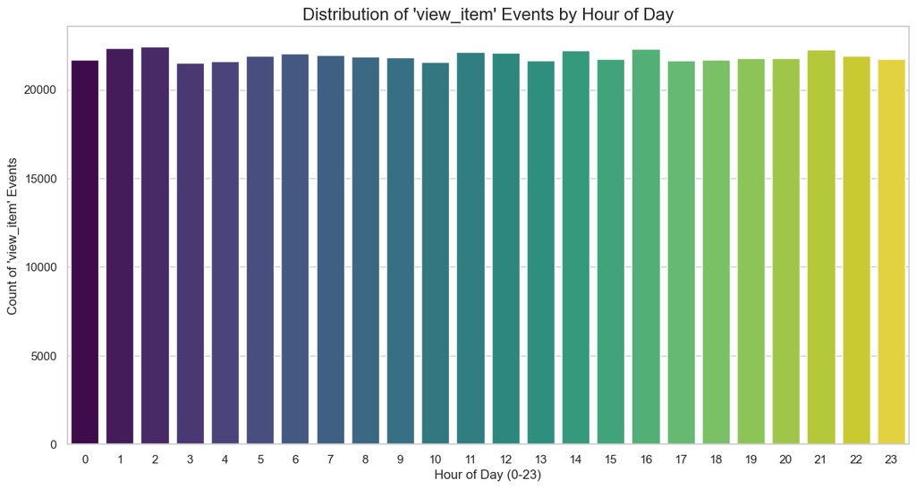

```python
if 'events_df_flat' in locals() and events_df_flat is not None:
    try:
        # --- Safety Check ---
        # Ensure the event_hour column exists before filtering
        if 'event_hour' not in events_df_flat.columns:
            print("Creating 'event_hour' column...")
            events_df_flat['event_time'] = pd.to_datetime(events_df_flat['event_time'])
            events_df_flat['event_hour'] = events_df_flat['event_time'].dt.hour
            print("Done.")
        # --- End Safety Check ---

        # 1. Create a new DataFrame with ONLY 'view_item' events
        df_views_only = events_df_flat[events_df_flat['event_name'] == 'view_item'].copy()

        if df_views_only.empty:
            print("No 'view_item' events found in the DataFrame.")
        else:
            # 2. Plot the count of these 'view_item' events by hour
            plt.figure(figsize=(14, 7))
            sns.countplot(
                x=df_views_only['event_hour'],
                hue=df_views_only['event_hour'],
                palette='viridis',
                legend=False
            )
            plt.title("Distribution of 'view_item' Events by Hour of Day", fontsize=16)
            plt.xlabel("Hour of Day (0-23)", fontsize=12)
            plt.ylabel("Count of 'view_item' Events", fontsize=12)
            plt.show()

    except Exception as e:
        print(f"An error occurred while plotting: {e}")
else:
    print("events_df_flat not loaded. Please re-run the full notebook.")
```

#### 2.E. Analyze User and Item IDs

```python
if events_df_flat is not None:
    print(f"Unique users in sample: {events_df_flat['user_id'].nunique()}")
    print(f"Unique items viewed in sample: {events_df_flat['parameter_value'].nunique()}")

    user_activity = events_df_flat['user_id'].value_counts()
    print("\n--- Top 5 Most Active Users (in sample) ---")
    print(user_activity.head())
else:
    print("events_df_flat not created. Skipping user/item ID analysis.")
```

```
Unique users in sample: 109624
Unique items viewed in sample: 5220

--- Top 5 Most Active Users (in sample) ---
user_id
148234.0    50
179533.0    44
110832.0    44
58607.0     44
51906.0     44
Name: count, dtype: int64
```

#### 2.F. Validate Join Key (event -> item)

```python
# Add error handling for casting `parameter_value`
try:
    event_item_ids = events_df_flat[
        events_df_flat['parameter_name'] == 'item_id']['parameter_value'].astype(float).unique()

    # 2. Get all item IDs from the item catalog
    catalog_item_ids = item_df['id'].unique()

    # 3. Check for referential integrity (are all event items in the catalog?)
    is_in_catalog = pd.Series(event_item_ids).isin(catalog_item_ids)
    all_items_exist = is_in_catalog.all()

    print(f"All item IDs from the event sample exist in item.csv: {all_items_exist}")

    if not all_items_exist:
        missing_ids = event_item_ids[~is_in_catalog]
        print("\n--- Missing Item IDs ---")
        print(f"Found {len(missing_ids)} item IDs that were viewed but are NOT in item.csv.")
        print("Showing up to 10 missing IDs:")
        print(missing_ids[:10])

except ValueError as e:
    print(f"Error casting 'parameter_value' to float: {e}")
    print("This could mean there are non-numeric item IDs in your event data.")
```

```
All item IDs from the event sample exist in item.csv: True
```